# Banning in League of Legends: Does it Matter?

# Introduction

#### What is League of Legends?

League of Legends (LoL) is a 3D, third person MOBA (Multiplayer Online Battle Arena) game developed by Riot Games. Released in October 2009, League recently has started it's first franchise year within North America, and currently has over 81 million players daily thoughout the world. Within the franchise year, there are some notable names such as Golden Guardians (Golden State Warriors), 100Thieves (Chicago Bulls), and Echo Fox (Rich Fox).

#### Gameplay

The premise of the game is simple: each game consists of two teams of 5 players, with one team labeled as red, and the other labeled as blue. Both team's primary objective is to destroy the opposing team's Nexus, which are located at the opposite sides of the map. Within the game, there are other side objectives to accumulate gold or experience to have an edge over the enemy team. Some of these side objectives are Dragon, Baron Nashor, Turrets, and Inhibitors. There are more than the four noted, but the common objective that they all share is that they are a point of pressure to draw the enemy towards your team to start a teamfight.

#### Bans

Banning champions is done before the game begins with each team given 5 bans to remove certain champions from the game. These champions may be excluded from the game because they percieved as OP (overpowered), unfair to play against, or to give an advantage for the match. Each team is given 5 bans for over 140 champions to pick, and after the ban phase, each player is required to pick one of the remaining ~130 champions that form some team compositons. Full details can be found here (https://na.leagueoflegends.com/en/).

#### Oracle's Elixer

A platform called Oracle's Elixir created by Tim "Magic" Sevenhuysen has collected multiple seasons worth of data for each professional match that has occurred within the past couple years. Along with this data release (http://oracleselixir.com/match-data/), he revealed that numerous coaches and analysts within the scene uses this data to gain a better idea at what the strengths and weaknesses are for each team and player. Given the interesting statistics they were able to find, the Oracle's Elixir decided to release the datasets as a way to allow members of the community to conduct anaylsis and start their esports career in some analyst or coaching positon.

#### Goals

In this tutorial, our goal is to tidy the in-game data given to us, provide valuable insight in determining if banning a champion matter in overall team's chances of winning. Although there are numerous of external factors that can't be quantify such as team compositon, type of day, comfort on the champion, and patch effect on champions, we can ignore these external factors. For readers unfamiliar with this game, we hope this analysis will make them interested in trying out League of Legends and provide some evidence on some go-to bans. For experienced players, we hope to show interesting unknown statistics and maybe even give new insights on reasoning behind bans.

## Part 1: Data Preparation and Getting Started

We will make use of Python 3 along with a few imported libraries: pandas, numpy, matplotlib, scikit-learn, seaborn, and more.  
pandas - https://pandas.pydata.org/pandas-docs/stable/  
matplotlib - https://matplotlib.org/contents.html  
seaborn - https://seaborn.pydata.org/

```python
# Necessary libraries and imports to complete this tutorial
import pandas as pd
import numpy as np
import matplotlib.pyplot as plt
import seaborn as sns
import warnings
warnings.filterwarnings('ignore')
```

The dataset we will be using can be found at the bottom of the data release (http://oracleselixir.com/match-data/) mentioned earlier. The dataset comes in the form of a CSV (Comma Separated Value) file.

## Part 1.1: Preprocssing the Data

```python
league = pd.read_csv("LoL.csv", sep=',')
league = league.dropna()
league
```

|  | league | split | date | week | game | side | position | player | team | champion | ban1 | ban2 | ban3 | ban4 | ban5 | result |
| --- | --- | --- | --- | --- | --- | --- | --- | --- | --- | --- | --- | --- | --- | --- | --- | --- |
| 0 | EULCS | 2018-2 | 43274.49209 | 2 | 2 | Blue | Top | Wunder | G2 Esports | Aatrox | Ryze | Zilean | Camille | Fiddlesticks | Rakan | 1.0 |
| 1 | EULCS | 2018-2 | 43274.49209 | 2 | 2 | Blue | Jungle | Jankos | G2 Esports | Braum | Ryze | Zilean | Camille | Fiddlesticks | Rakan | 1.0 |
| 2 | EULCS | 2018-2 | 43274.49209 | 2 | 2 | Blue | Middle | Perkz | G2 Esports | Lucian | Ryze | Zilean | Camille | Fiddlesticks | Rakan | 1.0 |
| 3 | EULCS | 2018-2 | 43274.49209 | 2 | 2 | Blue | ADC | Hjarnan | G2 Esports | Karma | Ryze | Zilean | Camille | Fiddlesticks | Rakan | 1.0 |
| 4 | EULCS | 2018-2 | 43274.49209 | 2 | 2 | Blue | Support | Wadid | G2 Esports | Alistar | Ryze | Zilean | Camille | Fiddlesticks | Rakan | 1.0 |
| 5 | EULCS | 2018-2 | 43274.49209 | 2 | 2 | Red | Top | Smittyj | H2K | Jax | Heimerdinger | Taliyah | Nocturne | Irelia | Zoe | 0.0 |
| 6 | EULCS | 2018-2 | 43274.49209 | 2 | 2 | Red | Jungle | Shook | H2K | Lee Sin | Heimerdinger | Taliyah | Nocturne | Irelia | Zoe | 0.0 |
| 7 | EULCS | 2018-2 | 43274.49209 | 2 | 2 | Red | Middle | Selfie | H2K | Vladimir | Heimerdinger | Taliyah | Nocturne | Irelia | Zoe | 0.0 |
| 8 | EULCS | 2018-2 | 43274.49209 | 2 | 2 | Red | ADC | Sheriff | H2K | Kai'Sa | Heimerdinger | Taliyah | Nocturne | Irelia | Zoe | 0.0 |
| 9 | EULCS | 2018-2 | 43274.49209 | 2 | 2 | Red | Support | promisq | H2K | Morgana | Heimerdinger | Taliyah | Nocturne | Irelia | Zoe | 0.0 |
| 10 | EULCS | 2018-2 | 43274.49209 | 2 | 2 | Blue | Team | Team | G2 Esports |  | Ryze | Zilean | Camille | Fiddlesticks | Rakan | 1.0 |
| 11 | EULCS | 2018-2 | 43274.49209 | 2 | 2 | Red | Team | Team | H2K |  | Heimerdinger | Taliyah | Nocturne | Irelia | Zoe | 0.0 |
| 12 | LCK | 2018-2 | 43263.10506 | 1.1 | 1 | Blue | Top | Crazy | BBQ Olivers | Shen | Nocturne | Camille | Irelia | Vladimir | Swain | 0.0 |
| 13 | LCK | 2018-2 | 43263.10506 | 1.1 | 1 | Blue | Jungle | Bono | BBQ Olivers | Nunu | Nocturne | Camille | Irelia | Vladimir | Swain | 0.0 |
| 14 | LCK | 2018-2 | 43263.10506 | 1.1 | 1 | Blue | Middle | Tempt | BBQ Olivers | Karthus | Nocturne | Camille | Irelia | Vladimir | Swain | 0.0 |
| 15 | LCK | 2018-2 | 43263.10506 | 1.1 | 1 | Blue | ADC | Aries | BBQ Olivers | Lucian | Nocturne | Camille | Irelia | Vladimir | Swain | 0.0 |
| 16 | LCK | 2018-2 | 43263.10506 | 1.1 | 1 | Blue | Support | IgNar | BBQ Olivers | Gragas | Nocturne | Camille | Irelia | Vladimir | Swain | 0.0 |
| 17 | LCK | 2018-2 | 43263.10506 | 1.1 | 1 | Red | Top | ADD | MVP | Ornn | Rakan | Taliyah | Graves | Alistar | Pyke | 1.0 |
| 18 | LCK | 2018-2 | 43263.10506 | 1.1 | 1 | Red | Jungle | Yondu | MVP | Master Yi | Rakan | Taliyah | Graves | Alistar | Pyke | 1.0 |
| 19 | LCK | 2018-2 | 43263.10506 | 1.1 | 1 | Red | Middle | Ian | MVP | Taric | Rakan | Taliyah | Graves | Alistar | Pyke | 1.0 |
| 20 | LCK | 2018-2 | 43263.10506 | 1.1 | 1 | Red | ADC | Pilot | MVP | Lulu | Rakan | Taliyah | Graves | Alistar | Pyke | 1.0 |
| 21 | LCK | 2018-2 | 43263.10506 | 1.1 | 1 | Red | Support | Max | MVP | Fiddlesticks | Rakan | Taliyah | Graves | Alistar | Pyke | 1.0 |
| 22 | LCK | 2018-2 | 43263.10506 | 1.1 | 1 | Blue | Team | Team | BBQ Olivers |  | Nocturne | Camille | Irelia | Vladimir | Swain | 0.0 |
| 23 | LCK | 2018-2 | 43263.10506 | 1.1 | 1 | Red | Team | Team | MVP |  | Rakan | Taliyah | Graves | Alistar | Pyke | 1.0 |
| 24 | LCK | 2018-2 | 43263.15271 | 1.1 | 2 | Blue | Top | ADD | MVP | Singed | Morgana | Yasuo | Nunu | Graves | Olaf | 1.0 |
| 25 | LCK | 2018-2 | 43263.15271 | 1.1 | 2 | Blue | Jungle | Yondu | MVP | Skarner | Morgana | Yasuo | Nunu | Graves | Olaf | 1.0 |
| 26 | LCK | 2018-2 | 43263.15271 | 1.1 | 2 | Blue | Middle | Ian | MVP | Irelia | Morgana | Yasuo | Nunu | Graves | Olaf | 1.0 |
| 27 | LCK | 2018-2 | 43263.15271 | 1.1 | 2 | Blue | ADC | Pilot | MVP | Lucian | Morgana | Yasuo | Nunu | Graves | Olaf | 1.0 |
| 28 | LCK | 2018-2 | 43263.15271 | 1.1 | 2 | Blue | Support | Max | MVP | Leona | Morgana | Yasuo | Nunu | Graves | Olaf | 1.0 |
| 29 | LCK | 2018-2 | 43263.15271 | 1.1 | 2 | Red | Top | Crazy | BBQ Olivers | Ornn | Taliyah | Master Yi | Camille | Nocturne | Shen | 0.0 |
| ... | ... | ... | ... | ... | ... | ... | ... | ... | ... | ... | ... | ... | ... | ... | ... | ... |
| 16158 | TCL | 2018-2p | 43359.30353 | F | 2 | Red | Jungle | Stomaged | SuperMassive | Xin Zhao | Draven | Irelia | Ryze | LeBlanc | Cassiopeia | 1.0 |
| 16159 | TCL | 2018-2p | 43359.30353 | F | 2 | Red | Middle | GBM | SuperMassive | Orianna | Draven | Irelia | Ryze | LeBlanc | Cassiopeia | 1.0 |
| 16160 | TCL | 2018-2p | 43359.30353 | F | 2 | Red | ADC | Zeitnot | SuperMassive | Ashe | Draven | Irelia | Ryze | LeBlanc | Cassiopeia | 1.0 |
| 16161 | TCL | 2018-2p | 43359.30353 | F | 2 | Red | Support | SnowFlower | SuperMassive | Tahm Kench | Draven | Irelia | Ryze | LeBlanc | Cassiopeia | 1.0 |
| 16162 | TCL | 2018-2p | 43359.30353 | F | 2 | Blue | Team | Team | Royal Bandits e-sports |  | Aatrox | Morgana | Akali | Gragas | Trundle | 0.0 |
| 16163 | TCL | 2018-2p | 43359.30353 | F | 2 | Red | Team | Team | SuperMassive |  | Draven | Irelia | Ryze | LeBlanc | Cassiopeia | 1.0 |
| 16164 | TCL | 2018-2p | 43359.36399 | F | 3 | Blue | Top | fabFabulous | SuperMassive | Aatrox | Draven | Irelia | Ryze | LeBlanc | Cassiopeia | 1.0 |
| 16165 | TCL | 2018-2p | 43359.36399 | F | 3 | Blue | Jungle | Stomaged | SuperMassive | Trundle | Draven | Irelia | Ryze | LeBlanc | Cassiopeia | 1.0 |
| 16166 | TCL | 2018-2p | 43359.36399 | F | 3 | Blue | Middle | GBM | SuperMassive | Orianna | Draven | Irelia | Ryze | LeBlanc | Cassiopeia | 1.0 |
| 16167 | TCL | 2018-2p | 43359.36399 | F | 3 | Blue | ADC | Zeitnot | SuperMassive | Varus | Draven | Irelia | Ryze | LeBlanc | Cassiopeia | 1.0 |
| 16168 | TCL | 2018-2p | 43359.36399 | F | 3 | Blue | Support | SnowFlower | SuperMassive | Braum | Draven | Irelia | Ryze | LeBlanc | Cassiopeia | 1.0 |
| 16169 | TCL | 2018-2p | 43359.36399 | F | 3 | Red | Top | Broken Blade | Royal Bandits e-sports | Sion | Urgot | Akali | Rakan | Gragas | Xin Zhao | 0.0 |
| 16170 | TCL | 2018-2p | 43359.36399 | F | 3 | Red | Jungle | Closer | Royal Bandits e-sports | Kindred | Urgot | Akali | Rakan | Gragas | Xin Zhao | 0.0 |
| 16171 | TCL | 2018-2p | 43359.36399 | F | 3 | Red | Middle | Abbedagge | Royal Bandits e-sports | Zoe | Urgot | Akali | Rakan | Gragas | Xin Zhao | 0.0 |
| 16172 | TCL | 2018-2p | 43359.36399 | F | 3 | Red | ADC | Freeze | Royal Bandits e-sports | Ashe | Urgot | Akali | Rakan | Gragas | Xin Zhao | 0.0 |
| 16173 | TCL | 2018-2p | 43359.36399 | F | 3 | Red | Support | Dumbledoge | Royal Bandits e-sports | Tahm Kench | Urgot | Akali | Rakan | Gragas | Xin Zhao | 0.0 |
| 16174 | TCL | 2018-2p | 43359.36399 | F | 3 | Blue | Team | Team | SuperMassive |  | Draven | Irelia | Ryze | LeBlanc | Cassiopeia | 1.0 |
| 16175 | TCL | 2018-2p | 43359.36399 | F | 3 | Red | Team | Team | Royal Bandits e-sports |  | Urgot | Akali | Rakan | Gragas | Xin Zhao | 0.0 |
| 16176 | TCL | 2018-2p | 43359.42644 | F | 4 | Blue | Top | Broken Blade | Royal Bandits e-sports | Urgot | Aatrox | Akali | Trundle | Orianna | Olaf | 0.0 |
| 16177 | TCL | 2018-2p | 43359.42644 | F | 4 | Blue | Jungle | Closer | Royal Bandits e-sports | Poppy | Aatrox | Akali | Trundle | Orianna | Olaf | 0.0 |
| 16178 | TCL | 2018-2p | 43359.42644 | F | 4 | Blue | Middle | Abbedagge | Royal Bandits e-sports | Ryze | Aatrox | Akali | Trundle | Orianna | Olaf | 0.0 |
| 16179 | TCL | 2018-2p | 43359.42644 | F | 4 | Blue | ADC | Freeze | Royal Bandits e-sports | Xayah | Aatrox | Akali | Trundle | Orianna | Olaf | 0.0 |
| 16180 | TCL | 2018-2p | 43359.42644 | F | 4 | Blue | Support | Dumbledoge | Royal Bandits e-sports | Rakan | Aatrox | Akali | Trundle | Orianna | Olaf | 0.0 |
| 16181 | TCL | 2018-2p | 43359.42644 | F | 4 | Red | Top | fabFabulous | SuperMassive | Ornn | Draven | Irelia | Pyke | Graves | Kindred | 1.0 |
| 16182 | TCL | 2018-2p | 43359.42644 | F | 4 | Red | Jungle | Stomaged | SuperMassive | Gragas | Draven | Irelia | Pyke | Graves | Kindred | 1.0 |
| 16183 | TCL | 2018-2p | 43359.42644 | F | 4 | Red | Middle | GBM | SuperMassive | Xerath | Draven | Irelia | Pyke | Graves | Kindred | 1.0 |
| 16184 | TCL | 2018-2p | 43359.42644 | F | 4 | Red | ADC | Zeitnot | SuperMassive | Varus | Draven | Irelia | Pyke | Graves | Kindred | 1.0 |
| 16185 | TCL | 2018-2p | 43359.42644 | F | 4 | Red | Support | SnowFlower | SuperMassive | Tahm Kench | Draven | Irelia | Pyke | Graves | Kindred | 1.0 |
| 16186 | TCL | 2018-2p | 43359.42644 | F | 4 | Blue | Team | Team | Royal Bandits e-sports |  | Aatrox | Akali | Trundle | Orianna | Olaf | 0.0 |
| 16187 | TCL | 2018-2p | 43359.42644 | F | 4 | Red | Team | Team | SuperMassive |  | Draven | Irelia | Pyke | Graves | Kindred | 1.0 |

6348 rows × 16 columns

The titles of each column should be self-explanatory. If you'd like to learn more about a column in the context of the game, important topics have links to the addition information here (http://oracleselixir.com/match-data/match-data-dictionary/).

```python
league.head()
```

|  | league | split | date | week | game | side | position | player | team | champion | ban1 | ban2 | ban3 | ban4 | ban5 | result |
| --- | --- | --- | --- | --- | --- | --- | --- | --- | --- | --- | --- | --- | --- | --- | --- | --- |
| 0 | EULCS | 2018-2 | 43274.49209 | 2 | 2 | Blue | Top | Wunder | G2 Esports | Aatrox | Ryze | Zilean | Camille | Fiddlesticks | Rakan | 1.0 |
| 1 | EULCS | 2018-2 | 43274.49209 | 2 | 2 | Blue | Jungle | Jankos | G2 Esports | Braum | Ryze | Zilean | Camille | Fiddlesticks | Rakan | 1.0 |
| 2 | EULCS | 2018-2 | 43274.49209 | 2 | 2 | Blue | Middle | Perkz | G2 Esports | Lucian | Ryze | Zilean | Camille | Fiddlesticks | Rakan | 1.0 |
| 3 | EULCS | 2018-2 | 43274.49209 | 2 | 2 | Blue | ADC | Hjarnan | G2 Esports | Karma | Ryze | Zilean | Camille | Fiddlesticks | Rakan | 1.0 |
| 4 | EULCS | 2018-2 | 43274.49209 | 2 | 2 | Blue | Support | Wadid | G2 Esports | Alistar | Ryze | Zilean | Camille | Fiddlesticks | Rakan | 1.0 |

## Part 2: Exploratory Data Analysis

For this section, there's not enough distinct, default colors for the graphs we will use. Thankfully, seaborn allows us to create a new palette of colors to use for graphing. Below is a set of distinct colors, and of course you can change whatever colors you like.

```python
colors = ["purple", "green", "blue", "pink", "brown", "red", "teal", "orange", "yellow", "grey", \
          "cyan", "bright green", "hot pink", "black", "maroon", "tan", "lavender", "goldenrod", "sky blue", "olive"]
new_palette = sns.xkcd_palette(colors)
```

#### If Zoe is banned, is her team more or less likely to win (or neither)?

For starters, we'll ask a simple question. If the champion Zoe is banned, does this make her team more likely to win? Does it make a difference? First, we need to extract matches in which Zoe is banned. Let's keep blue and red bans separate for now, since this might make answering the question easier later.

**First, we'll get the matches when the blue team banned Zoe**

```python
blueban =  league[(league.side == "Blue") & (league.position == "Team")]
bluezoeban = blueban[((league.ban1 == "Zoe") | (league.ban2 == "Zoe") | (league.ban3 == "Zoe") | (league.ban4 == "Zoe") | (league.ban5 == "Zoe"))]
bluezoeban.head()
```

|  | league | split | date | week | game | side | position | player | team | champion | ban1 | ban2 | ban3 | ban4 | ban5 | result |
| --- | --- | --- | --- | --- | --- | --- | --- | --- | --- | --- | --- | --- | --- | --- | --- | --- |
| 94 | LCK | 2018-2 | 43264.03627 | 1.2 | 2 | Blue | Team | Team | Gen.G |  | Zoe | Irelia | Lucian | Jayce | Ornn | 1.0 |
| 130 | LCK | 2018-2 | 43264.15736 | 1.2 | 2 | Blue | Team | Team | SK Telecom T1 |  | Nocturne | Zoe | Taliyah | Alistar | Fiddlesticks | 0.0 |
| 154 | LCK | 2018-2 | 43264.28487 | 1.2 | 2 | Blue | Team | Team | Jin Air Green Wings |  | Graves | Camille | Zoe | Renekton | Shen | 0.0 |
| 262 | EULCS | 2018-2 | 43266.60719 | 1 | 1 | Blue | Team | Team | Fnatic |  | Zoe | Yasuo | Taliyah | Fiddlesticks | Vladimir | 0.0 |
| 298 | LCK | 2018-2 | 43266.20351 | 1.4 | 3 | Blue | Team | Team | Jin Air Green Wings |  | Irelia | Shen | Zoe | Morgana | Ezreal | 0.0 |

```python
print ("Zoe was banned " + str(len(bluezoeban)) +  " times out of " + str(len(blueban)) + " Blue side games (" + str(len(bluezoeban)*100/len(blueban)) + "%)")
```

```
Zoe was banned 103 times out of 529 Blue side games (19.47069943289225%)
```

**And we'll do the same for the red team**

```python
redban =  league[(league.side == "Red") & (league.position == "Team")]
redzoeban = redban[((league.ban1 == "Zoe") | (league.ban2 == "Zoe") | (league.ban3 == "Zoe") | (league.ban4 == "Zoe") | (league.ban5 == "Zoe"))]
redzoeban.head()
```

|  | league | split | date | week | game | side | position | player | team | champion | ban1 | ban2 | ban3 | ban4 | ban5 | result |
| --- | --- | --- | --- | --- | --- | --- | --- | --- | --- | --- | --- | --- | --- | --- | --- | --- |
| 11 | EULCS | 2018-2 | 43274.49209 | 2 | 2 | Red | Team | Team | H2K |  | Heimerdinger | Taliyah | Nocturne | Irelia | Zoe | 0.0 |
| 107 | LCK | 2018-2 | 43264.06755 | 1.2 | 3 | Red | Team | Team | Gen.G |  | Taliyah | Zoe | Irelia | Jayce | Darius | 1.0 |
| 119 | LCK | 2018-2 | 43264.1022 | 1.2 | 1 | Red | Team | Team | SK Telecom T1 |  | Taliyah | Taric | Karthus | Jayce | Zoe | 0.0 |
| 179 | LCK | 2018-2 | 43265.15869 | 1.3 | 2 | Red | Team | Team | Hanwha Life Esports |  | Taliyah | Master Yi | Zoe | Kennen | Pyke | 1.0 |
| 239 | EULCS | 2018-2 | 43266.534 | 1 | 1 | Red | Team | Team | Unicorns of Love |  | Zoe | Lulu | Irelia | Ryze | Fizz | 0.0 |

```python
print ("Zoe was banned " + str(len(redzoeban)) +  " times out of " + str(len(redban)) + " Red side games (" + str(len(redzoeban)*100/len(redban)) + "%)")
```

```
Zoe was banned 94 times out of 529 Red side games (17.76937618147448%)
```

#### Now we want all the matches where Zoe was banned by at least one team, then we could get it with:

```python
print ("Zoe was banned " + str(len(redzoeban) + len(bluezoeban)) +  " times out of " + str(len(redban)) + " games (" + str((len(redzoeban) + len(bluezoeban))*100/len(redban)) + "%)")
```

```
Zoe was banned 197 times out of 529 games (37.24007561436673%)
```

#### Now let's look at the overall ban rate compared to total games played.

```python
total_games = league[league.position == 'Team']
num_games = len(total_games)/2
ban_rate =  (len(redzoeban) + len(bluezoeban))/num_games
print (ban_rate * 100)
```

```
37.24007561436673
```

**And if we wanted all the matches where Zoe was banned by both teams, we can do an intersection of the two**

```python
(redban & blueban).dropna()
```

|  | league | split | date | week | game | side | position | player | team | champion | ban1 | ban2 | ban3 | ban4 | ban5 | result |
| --- | --- | --- | --- | --- | --- | --- | --- | --- | --- | --- | --- | --- | --- | --- | --- | --- |

The result should be to be expected because both teams cannot ever both ban the same champions especially in competitive. This is a nice check though.

**For each team that banned Zoe, how many of those matches did the team win?**

```python
redzoebanwin = redzoeban[redzoeban.result == 1]
print("When Zoe was banned on the Red side, they won " + str(len(redzoebanwin)) + " out of " + str(len(redzoeban)) + " games (" + str(len(redzoebanwin)*100/len(redzoeban)) + "%)")
print("and lost " + str(len(redzoeban)-len(redzoebanwin)) + " out of " + str(len(redzoeban)) + " games (" + str(100-(len(redzoebanwin)*100/len(redzoeban))) + "%)")

bluezoebanwin = bluezoeban[bluezoeban.result == 1]
print("When Zoe was banned on the Blue side, they won " + str(len(bluezoebanwin)) + " out of " + str(len(bluezoeban)) + " games (" + str(len(bluezoebanwin)*100/len(bluezoeban)) + "%)")
print("and lost " + str(len(bluezoeban)-len(bluezoebanwin)) + " out of " + str(len(bluezoeban)) + " games (" + str(100-(len(bluezoebanwin)*100/len(bluezoeban))) + "%)")
```

```
When Zoe was banned on the Red side, they won 34 out of 94 games (36.170212765957444%)
and lost 60 out of 94 games (63.829787234042556%)
When Zoe was banned on the Blue side, they won 50 out of 103 games (48.54368932038835%)
and lost 53 out of 103 games (51.45631067961165%)
```

After the ban phase, the winrate is based more heavily on the team's execution of the game instead of solely on this one champion being banned because in all of these cases, the Zoe ban is the control variable since it is not changing in any of these cases.

**Who is the most banned character? Does banning this character make your team more likely to win?**

We want to take the task some conventional wisdom that may be floating around the community about which characters you should ban if you want to increase your chances to win. Let's see if this holds water.

First we need to find the most banned character. Probably lots of ways to get at this, but one thign we can do is a groupy by each ban slot as before, for each building a dictionary giving banned champions as keys and the number of matches they were banned in as values:

```python
allbans = league[(league.position == "Team")][league.columns[9:15]]
bans1 = allbans['ban1'].value_counts()
bans2 = allbans['ban2'].value_counts()
bans3 = allbans['ban3'].value_counts()
bans4 = allbans['ban4'].value_counts()
bans5 = allbans['ban5'].value_counts()
bans = bans1.add(bans2, fill_value=0).add(bans3, fill_value=0).add(bans4, fill_value=0).add(bans5, fill_value=0)
bans.sort_values(ascending=False)
bansdf = pd.DataFrame(bans).rename(columns={0: 'bancount'})
bansdf = bansdf.sort_values(by='bancount',ascending=False)
bansdf.head()
```

|  | bancount |
| --- | --- |
| Aatrox | 347.0 |
| Taliyah | 339.0 |
| Rakan | 257.0 |
| Nocturne | 242.0 |
| Zoe | 197.0 |

So we have our answer. The most banned champion across the major regions is **Aatrox**.

Out of curiosity, what's the distribution of bans look like acrosss champions?

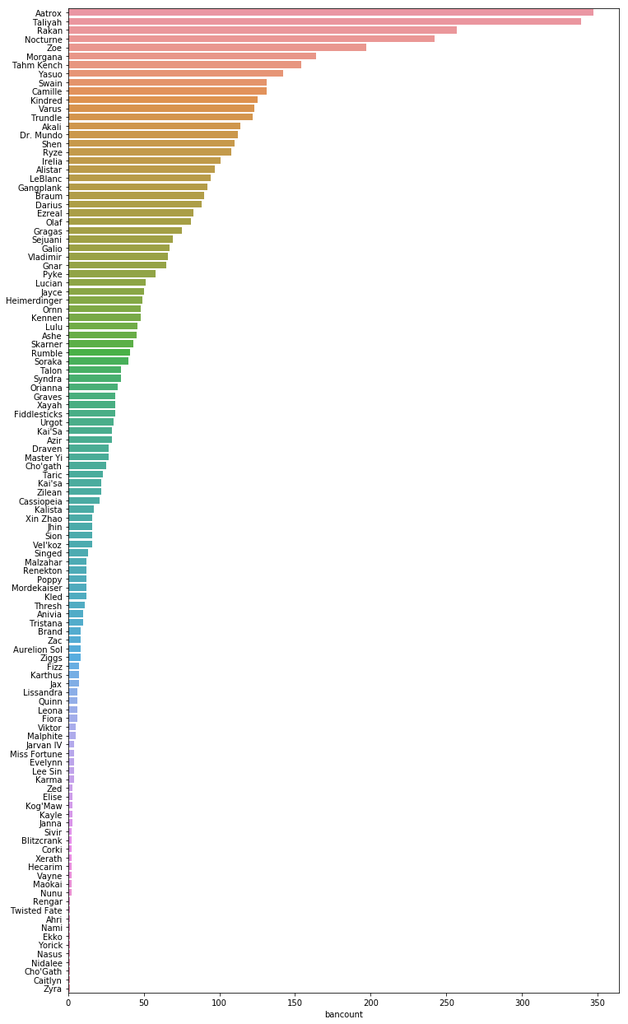

```python
a4_dims = (12, 22)
fig, ax = plt.subplots(figsize=a4_dims)
sns.barplot(y=bansdf.index, x='bancount', data=bansdf, ax=ax)
```

**Does banning Aatrox make you more likely to win?**

Lets do the same analysis for Aatrox as we did for Zoe

```python
redban =  league[(league.side == "Red") & (league.position == "Team")]
redaatroxban = redban[((league.ban1 == "Aatrox") | (league.ban2 == "Aatrox") | (league.ban3 == "Aatrox") | (league.ban4 == "Aatrox") | (league.ban5 == "Aatrox"))]
redaatroxban.head()
```

|  | league | split | date | week | game | side | position | player | team | champion | ban1 | ban2 | ban3 | ban4 | ban5 | result |
| --- | --- | --- | --- | --- | --- | --- | --- | --- | --- | --- | --- | --- | --- | --- | --- | --- |
| 251 | EULCS | 2018-2 | 43266.57421 | 1 | 1 | Red | Team | Team | Roccat |  | Irelia | Taliyah | Taric | Aatrox | Ezreal | 0.0 |
| 359 | EULCS | 2018-2 | 43267.4766 | 1 | 2 | Red | Team | Team | Giants Gaming |  | Zoe | Irelia | Aatrox | Heimerdinger | Thresh | 0.0 |
| 431 | NALCS | 2018-2 | 43267.82233 | 1 | 1 | Red | Team | Team | OpTic Gaming |  | Taliyah | Zoe | Irelia | Aatrox | Singed | 1.0 |
| 515 | LCK | 2018-2 | 43268.09726 | 1.6 | 1 | Red | Team | Team | Gen.G |  | Singed | Irelia | Fiddlesticks | Aatrox | Camille | 1.0 |
| 587 | NALCS | 2018-2 | 43268.73743 | 1 | 2 | Red | Team | Team | Echo Fox |  | Zoe | Lulu | Morgana | Aatrox | Vladimir | 1.0 |

```python
blueban =  league[(league.side == "Blue") & (league.position == "Team")]
blueaatroxban = blueban[((league.ban1 == "Aatrox") | (league.ban2 == "Aatrox") | (league.ban3 == "Aatrox") | (league.ban4 == "Aatrox") | (league.ban5 == "Aatrox"))]
blueaatroxban.head()
```

|  | league | split | date | week | game | side | position | player | team | champion | ban1 | ban2 | ban3 | ban4 | ban5 | result |
| --- | --- | --- | --- | --- | --- | --- | --- | --- | --- | --- | --- | --- | --- | --- | --- | --- |
| 226 | EULCS | 2018-2 | 43266.48133 | 1 | 1 | Blue | Team | Team | H2K |  | Ryze | Graves | Vladimir | Shen | Aatrox | 0.0 |
| 334 | EULCS | 2018-2 | 43267.38645 | 1 | 2 | Blue | Team | Team | Roccat |  | Ryze | Taric | Darius | Aatrox | Dr. Mundo | 1.0 |
| 550 | NALCS | 2018-2 | 43268.56992 | 1 | 2 | Blue | Team | Team | Team SoloMid |  | Taliyah | Morgana | Nocturne | Renekton | Aatrox | 1.0 |
| 670 | LCK | 2018-2 | 43270.28596 | 2.1 | 2 | Blue | Team | Team | BBQ Olivers |  | Shen | Mordekaiser | Aatrox | Braum | Dr. Mundo | 0.0 |
| 706 | LCK | 2018-2 | 43271.07306 | 2.2 | 1 | Blue | Team | Team | SK Telecom T1 |  | Master Yi | Irelia | Zoe | Singed | Aatrox | 1.0 |

```python
print ("Aatrox was banned " + str(len(redaatroxban)) +  " times out of " + str(len(redban)) + " Red side games (" + str(len(redaatroxban)*100/len(redban)) + "%)")
print ("Aatrox was banned " + str(len(blueaatroxban)) +  " times out of " + str(len(blueban)) + " Blue side games (" + str(len(blueaatroxban)*100/len(blueban)) + "%)")
```

```
Aatrox was banned 283 times out of 529 Red side games (53.497164461247635%)
Aatrox was banned 64 times out of 529 Blue side games (12.098298676748582%)
```

Let's look at the overall ban rate compared to total games played for the most banned champion

```python
print ("In total, Aatrox was banned "+ str(len(redaatroxban) + len(blueaatroxban)) + " out of " + str(len(blueban)) + " games (" + str((len(redaatroxban)+len(blueaatroxban))*100/len(redban)) + "%)")
```

```
In total, Aatrox was banned 347 out of 529 games (65.59546313799622%)
```

Aatrox seems to have a significantly high ban rate for some reason. Let's try to figure out why!

**In a game where Aatrox wasn't banned, was he picked? Was the team more likely win?**

First we need matches where Aatrox was not banned. We'll get the games where Aatrox was picked. From there we will look at the dataframe and look at the games where it was picked and they won.

```python
picked = league[league.champion == 'Aatrox']
picked_win = picked[picked.result == 1]
print("Out of the "+ str(len(picked)) +" times Aatrox was picked, he won " + str(len(picked_win)) + " times (" + str(len(picked_win) * 100/len(picked)) + "%)")
```

```
Out of the 91 times Aatrox was picked, he won 60 times (65.93406593406593%)
```

As we can see from the data the most banned champion has a ~66% win rate when picked, which is substantially high considering that out of 91 games, there is still a 66% win rate, which gives indication that either the champion at the time of the season gives the team such an advantage that it swings their chances of winning more often than not.

```python
picked = league[league.champion == 'Aatrox']
total_games = league[league.position == 'Team']
num_games = len(total_games)/2
picked_rate = (len(picked)/(num_games-(len(blueaatroxban) + len(redaatroxban))))
print ("When he is not banned, Aatrox is picked " + str(picked_rate * 100) + "% of the time")
```

```
When he is not banned, Aatrox is picked 50.0% of the time
```

As we can see the most banned champion is banned ~66% of the games and of those games that aren't there is a win rate of ~66%. If we take this into perspective Aatrox is picked approximately half of the time it's up if not banned and of those times, the team with Aatrox has a win rate of 66%. In addition, this makes Aatrox have 83% of games picked or banned.

**Now let's look at the second most banned champion (Taliyah) and we'll do the same analysis**

```python
picked = league[league.champion == 'Taliyah']
picked_win = picked[picked.result == 1]
print("Out of the "+ str(len(picked)) +" times Taliyah was picked, they won " + str(len(picked_win)) + " times (" + str(len(picked_win) * 100/len(picked)) + "%)")
```

```
Out of the 75 times Taliyah was picked, they won 45 times (60.0%)
```

As we can see from the data, the second most banned champion has a 60% win rate when picked. We can see from these two data points, that there may be correlation between the most banned champions and win rate. We can see that often times, those most banned have more than a 50% win rate causing teams that play against these champions to be a greater disadvantage of winning.

#### Other questions we can ask...

There are many other questions we can ask and even complex ones are surprisingly easy to do because of the way that we have structured our data.

Here are a few:

```
1: Is there any champion that seems to confer a systematic advantage
   to the team that has it? If it appears so, can we isolate the
   effect from other possible factors?

2: Is there any combination of champion bans that make a team more
   likely to win? Does it depend heavily on the team?

3: Which teams ban the same champions the most? Can we guess why
   from the data?
```